# 11-Arima

## Non Seasonal

Now we do the same but with the seasonal option turned to false

```python
model2=pmdarima.auto_arima(train_data,start_p=0,d=0,start_q=0,
          max_p=5,max_d=5,max_q=5, start_P=0,
          D=1, start_Q=0, max_P=5,max_D=1,
          max_Q=5, m=12, seasonal=False,
          error_action='warn',trace=True,
          supress_warnings=True,stepwise=True,
          random_state=20,n_fits=50)
```

```
Performing stepwise search to minimize aic
 ARIMA(0,0,0)(0,0,0)[0]             : AIC=4677.411, Time=0.01 sec
 ARIMA(1,0,0)(0,0,0)[0]             : AIC=4677.893, Time=0.02 sec
 ARIMA(0,0,1)(0,0,0)[0]             : AIC=4677.722, Time=0.02 sec
 ARIMA(1,0,1)(0,0,0)[0]             : AIC=4675.808, Time=0.08 sec
 ARIMA(2,0,1)(0,0,0)[0]             : AIC=4677.401, Time=0.11 sec
 ARIMA(1,0,2)(0,0,0)[0]             : AIC=4677.441, Time=0.19 sec
 ARIMA(0,0,2)(0,0,0)[0]             : AIC=4677.903, Time=0.06 sec
 ARIMA(2,0,0)(0,0,0)[0]             : AIC=4678.490, Time=0.03 sec
 ARIMA(2,0,2)(0,0,0)[0]             : AIC=4675.513, Time=0.26 sec
 ARIMA(3,0,2)(0,0,0)[0]             : AIC=4677.484, Time=0.39 sec
 ARIMA(2,0,3)(0,0,0)[0]             : AIC=4677.484, Time=0.49 sec
 ARIMA(1,0,3)(0,0,0)[0]             : AIC=4678.986, Time=0.23 sec
 ARIMA(3,0,1)(0,0,0)[0]             : AIC=4678.834, Time=0.15 sec
 ARIMA(3,0,3)(0,0,0)[0]             : AIC=4679.708, Time=0.63 sec
 ARIMA(2,0,2)(0,0,0)[0] intercept   : AIC=4676.843, Time=0.43 sec

Best model:  ARIMA(2,0,2)(0,0,0)[0]
Total fit time: 3.086 seconds
```

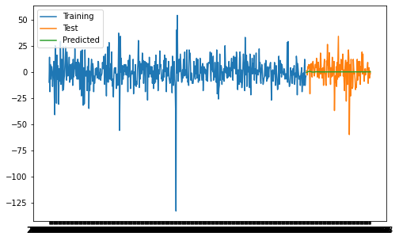

```python
pred = pd.DataFrame(model2.predict(len(test_data)))
pred.columns = ["prediction"]
pred.index = test_data.index
plt.figure(figsize=(8,5))
plt.plot(train_data,label="Training")
plt.plot(test_data,label="Test")
plt.plot(pred,label="Predicted")
plt.legend(loc = 'upper left')
plt.savefig('SecondPrection.jpg')
plt.show()
```

## Changing the size of train data

Now we change size of train and test data. We will take 90% of the data for training and 10% for test

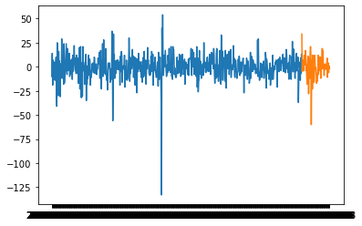

```python
train_data, test_data = train_test(series_diff,0.9)

plt.plot(train_data)
plt.plot(test_data)
```

```python
model3=pmdarima.auto_arima(train_data,start_p=0,d=0,start_q=0,
          max_p=5,max_d=5,max_q=5, start_P=0,
          D=1, start_Q=0, max_P=5,max_D=1,
          max_Q=5, m=12, seasonal=True,
          error_action='warn',trace=True,
          supress_warnings=True,stepwise=True,
          random_state=20,n_fits=50)
```

```
Performing stepwise search to minimize aic
 ARIMA(0,0,0)(0,1,0)[12] intercept   : AIC=5616.163, Time=0.06 sec
 ARIMA(1,0,0)(1,1,0)[12] intercept   : AIC=5420.166, Time=0.84 sec
 ARIMA(0,0,1)(0,1,1)[12] intercept   : AIC=inf, Time=1.56 sec
 ARIMA(0,0,0)(0,1,0)[12]             : AIC=5614.168, Time=0.03 sec
 ARIMA(1,0,0)(0,1,0)[12] intercept   : AIC=5614.981, Time=0.15 sec
 ARIMA(1,0,0)(2,1,0)[12] intercept   : AIC=5360.464, Time=2.93 sec
 ARIMA(1,0,0)(3,1,0)[12] intercept   : AIC=5319.891, Time=5.94 sec
 ARIMA(1,0,0)(4,1,0)[12] intercept   : AIC=5289.716, Time=10.28 sec
 ARIMA(1,0,0)(5,1,0)[12] intercept   : AIC=5272.491, Time=46.99 sec
 ARIMA(1,0,0)(5,1,1)[12] intercept   : AIC=inf, Time=117.59 sec
 ARIMA(1,0,0)(4,1,1)[12] intercept   : AIC=inf, Time=22.75 sec
 ARIMA(0,0,0)(5,1,0)[12] intercept   : AIC=5271.263, Time=41.32 sec
 ARIMA(0,0,0)(4,1,0)[12] intercept   : AIC=5288.871, Time=13.41 sec
 ARIMA(0,0,0)(5,1,1)[12] intercept   : AIC=inf, Time=119.79 sec
 ARIMA(0,0,0)(4,1,1)[12] intercept   : AIC=inf, Time=20.63 sec
 ARIMA(0,0,1)(5,1,0)[12] intercept   : AIC=5272.370, Time=41.89 sec
 ARIMA(1,0,1)(5,1,0)[12] intercept   : AIC=5270.132, Time=68.06 sec
 ARIMA(1,0,1)(4,1,0)[12] intercept   : AIC=5287.858, Time=15.98 sec
 ARIMA(1,0,1)(5,1,1)[12] intercept   : AIC=inf, Time=137.19 sec
 ARIMA(1,0,1)(4,1,1)[12] intercept   : AIC=inf, Time=27.96 sec
 ARIMA(2,0,1)(5,1,0)[12] intercept   : AIC=5270.659, Time=74.89 sec
 ARIMA(1,0,2)(5,1,0)[12] intercept   : AIC=5270.781, Time=84.74 sec
 ARIMA(0,0,2)(5,1,0)[12] intercept   : AIC=5270.921, Time=50.45 sec
 ARIMA(2,0,0)(5,1,0)[12] intercept   : AIC=5271.650, Time=49.74 sec
 ARIMA(2,0,2)(5,1,0)[12] intercept   : AIC=5271.896, Time=86.91 sec
 ARIMA(1,0,1)(5,1,0)[12]             : AIC=5268.179, Time=14.40 sec
 ARIMA(1,0,1)(4,1,0)[12]             : AIC=5285.892, Time=4.59 sec
 ARIMA(1,0,1)(5,1,1)[12]             : AIC=inf, Time=117.53 sec
 ARIMA(1,0,1)(4,1,1)[12]             : AIC=inf, Time=26.44 sec
 ARIMA(0,0,1)(5,1,0)[12]             : AIC=5270.404, Time=6.49 sec
 ARIMA(1,0,0)(5,1,0)[12]             : AIC=5270.525, Time=8.51 sec
 ARIMA(2,0,1)(5,1,0)[12]             : AIC=5268.706, Time=15.12 sec
 ARIMA(1,0,2)(5,1,0)[12]             : AIC=5268.828, Time=16.63 sec
 ARIMA(0,0,0)(5,1,0)[12]             : AIC=5269.295, Time=6.62 sec
 ARIMA(0,0,2)(5,1,0)[12]             : AIC=5268.962, Time=9.90 sec
 ARIMA(2,0,0)(5,1,0)[12]             : AIC=5269.689, Time=8.52 sec
 ARIMA(2,0,2)(5,1,0)[12]             : AIC=5269.940, Time=15.41 sec

Best model:  ARIMA(1,0,1)(5,1,0)[12]
Total fit time: 1292.324 seconds
```

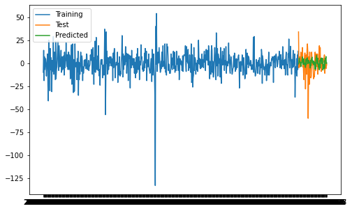

```python
pred = pd.DataFrame(model3.predict(len(test_data)))
pred.columns = ["prediction"]
pred.index = test_data.index
plt.figure(figsize=(8,5))
plt.plot(train_data,label="Training")
plt.plot(test_data,label="Test")
plt.plot(pred,label="Predicted")
plt.legend(loc = 'upper left')
plt.savefig('SecondPrection.jpg')
plt.show()
```

The predictions seem are still pretty bad. We can zoom in to see better

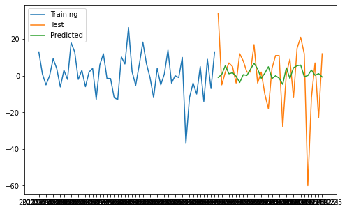

```python
pred = pd.DataFrame(model3.predict(len(test_data)))
pred.columns = ["prediction"]
pred.index = test_data.index
plt.figure(figsize=(8,5))
plt.plot(train_data[-50:],label="Training")
plt.plot(test_data[:30],label="Test")
plt.plot(pred[:30],label="Predicted")
plt.legend(loc = 'upper left')
plt.savefig('SecondPrection.jpg')
plt.show()
```

As said before, the prediction isnt very good, though at times the maximums and minimums of the prediction seem to align with the test data